# Grappling with the “Attention to feelings” scale

Last updated 2018-04-07

Here we look at the “attention to feelings” scale (Salovey et al.; Packet 2) in detail.

# Differences across fieldsites

## Mean scores by site

First, let’s look at scores for participants in each site:

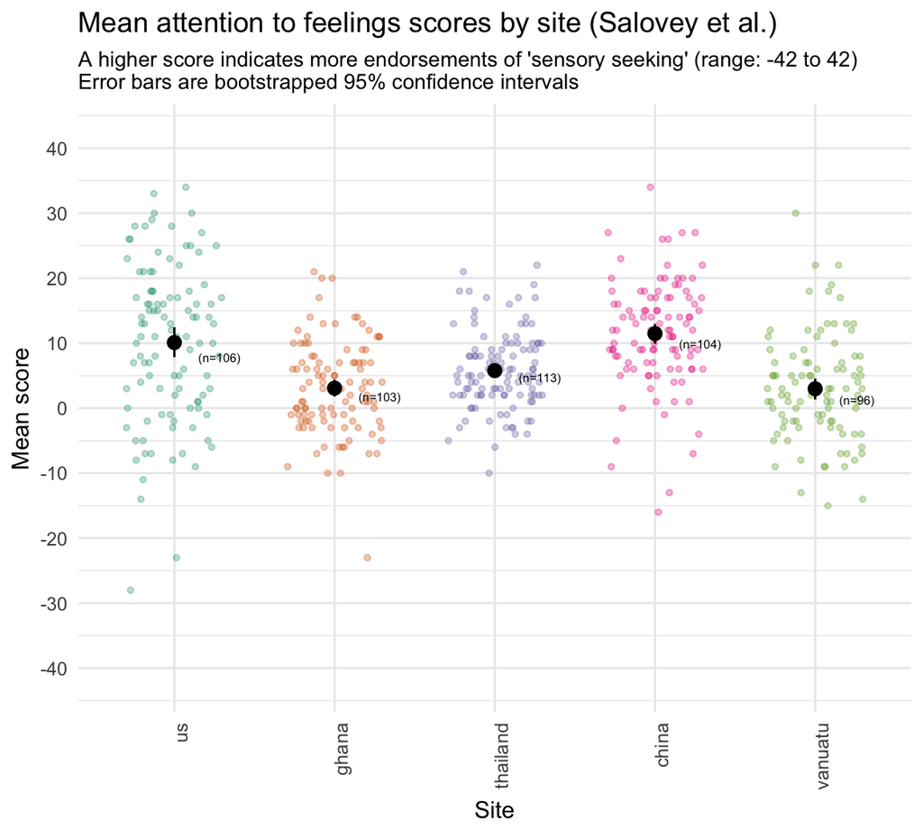

Note that this plot includes both average scores for each site (in black), and individual scores for all of the participants in that site (small, colorful points in the background, which are “jittered” around a little so that you can see them all).

Looks like people in different sites responded somewhat differently to this scale. Participants in the US and China responded substantially more positively.

Bear in mind when interpreting this that this is one of the few scales that included a substantial number of reverse-coded items - which would reduce any general “positive” (or “negative”) response biases/tendencies. So this could be interpreted as evidence that the relatively higher positive responses observed in VT (and to some extent GH) could be due at least in part to how participants were using the scale… This logic works especially well if we think this scale should have measured the same underlying constructs as other “bodily” kinds of scales… Anyway, food for thought/discussion.

Now let’s look at these differences in more detail using the “raw data” for individual questions, rather than these subscale scores.

## Responses by question, by site

```
Column `question` joining character vector and factor, coercing into character vectorIgnoring unknown aesthetics: fill
```

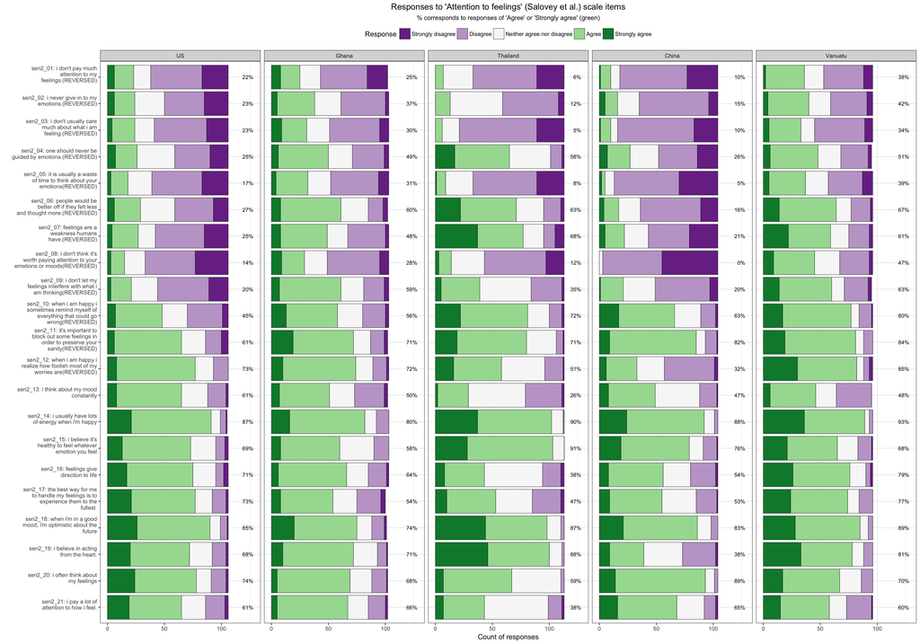

**NOTE**: This scale has **many reverse-coded items** (`sen2_01` - `sen_12`; marged on the plot). These are *not* reverse-coded in this plot - i.e., if people selected “Disagree” for one of these items, it’s plotted here as “Disagree.” (For the previous plots of overall “scores,” these items were reverse-coded before being entered into the scoring.)

As always, lots to chew on here. Off the top of my head, a few things stand out:

- More use of the neutral midpoint in TH … and maybe CH?
- At a glance, it seems like people in VT used the “disagree” end of the scale (purple) a little less often than others, and might have distinguished less between the reverse-coded items (#1-12, top of plot) and the non-reverse-coded items (#13-21, bottom of plot). This is the strongest hint we have so far that people in VT might have been reluctant to use the “disagree” end of these scales - i.e., they might have had a different response bias/strategy than participants in other sites.
- At the same time, there are some (theoretically) “reverse-coded” items (e.g., `sen2_04`, `sen2_06`, `sen2_07`: all kind of about emotions as a weakness - see also `sen2_16`) that TH participants tended to agree with, although they tended to disagree with the other reverse-coded items. A little bit of non-contradiction here? (**Emily**, **Felicity** - thoughts??) (This raises the possibility that participants in VT were also being even more radically tolerant of contradiction… but the acquiescence/agreeableness idea seems a more likely to me.) Totally interesting.
- Participants in CH were strikingly less likely than people in other sites to agree with the item, “When I am happy I realize how foolish most of my worries are” (`sen2_12`).
- Interesting variability in the “healthiness” of “whatever emotion you feel” (`sen2_15`): Strong support in TH, more skepticism about this in GH and VT (all the more striking because of the generally “agreeable” responses in VT).

And so much more…

Again, **Josh**, you’ve gotta take a look at these with an eye toward a ratio! Maybe we should fold them into the “ratio of senses” doc…

# Distribution of responses for individual participants, by site

Another thing we might be interested in is how individual participants responded: Were there people who said yes to everything, or no to everything? How do these distributions of responses differ across participants in different sites?

Let’s take a look:

```
Column `question` joining character vector and factor, coercing into character vector
```

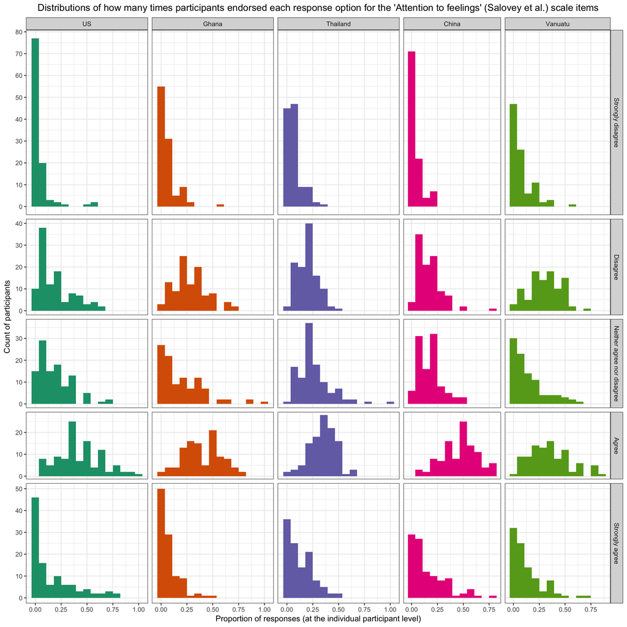

Have not looked closely at this yet, but we should.

Just for fun, here’s another way to look at the same data, overlaying the density distributions for each site on top of each other to see where they seem to be similar/different:

```
Column `question` joining character vector and factor, coercing into character vector
```

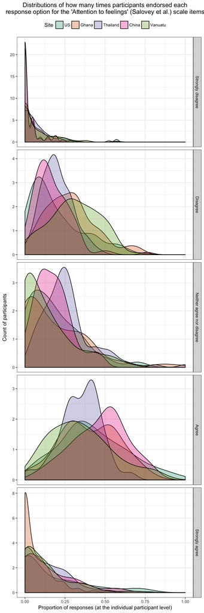